# Exercise02

Ken Suzuki

2023-10-25

A researcher is interested in studying potential predictors of income differences among individuals. More specifically, she would like to predict income (REALINC) from sex (SEX), occupational prestige (PRESTG80), religion (RELIG) and number of hours worked per week (HRS1). Using the dataset ‘us_gss_1991.csv’ (subset of the 1991 United States General Social Survey, available on eClass), address the following. Use α = .01 for null hypothesis testing.

#### 1.Run a general linear model (GLM) predicting income from sex, occupational prestige, religion and number of hours worked per week.

```r
# Road the data
d <- read.csv("~/Desktop/P4330/P4330 R code/Exercise01/Exercise02/Exercise02/us_gss_1991.csv")

# Review the data structures
str(d)
```

```
## 'data.frame':    825 obs. of  5 variables:
##  $ REALINC : int  6267 90265 90265 9401 90265 19846 90265 17757 22980 31336 ...
##  $ SEX     : chr  "Female" "Female" "Male" "Female" ...
##  $ PRESTG80: int  22 75 59 42 38 36 65 49 50 32 ...
##  $ RELIG   : chr  "Catholic" "Jewish" "Other" "None" ...
##  $ HRS1    : int  40 20 50 20 30 40 40 40 50 40 ...
```

```r
# Convert Character to factor
d$RELIG <- factor(d$RELIG)

# Check the levels
levels(d$RELIG)
```

```
## [1] "Catholic"   "Jewish"     "None"       "Other"      "Protestant"
```

```r
# Run a linear model as m and show summary
m <-  lm(REALINC ~ SEX + PRESTG80 + RELIG + HRS1, data = d)
summary(m)
```

```
##
## Call:
## lm(formula = REALINC ~ SEX + PRESTG80 + RELIG + HRS1, data = d)
##
## Residuals:
##    Min     1Q Median     3Q    Max
## -45793 -13764  -4409   9402  68222
##
## Coefficients:
##                 Estimate Std. Error t value Pr(>|t|)
## (Intercept)      3159.13    3240.78   0.975 0.329945
## SEXMale          5426.48    1463.78   3.707 0.000224 ***
## PRESTG80          528.48      53.27   9.921  < 2e-16 ***
## RELIGJewish     16848.70    4885.85   3.448 0.000593 ***
## RELIGNone       -3147.08    2792.19  -1.127 0.260031
## RELIGOther       3686.54    4968.91   0.742 0.458348
## RELIGProtestant -2263.78    1664.23  -1.360 0.174123
## HRS1               92.69      50.19   1.847 0.065111 .
## ---
## Signif. codes:  0 '***' 0.001 '**' 0.01 '*' 0.05 '.' 0.1 ' ' 1
##
## Residual standard error: 20190 on 817 degrees of freedom
## Multiple R-squared:  0.1616, Adjusted R-squared:  0.1545
## F-statistic:  22.5 on 7 and 817 DF,  p-value: < 2.2e-16
```

```r
# Obtain Confident Intervals
confint(m)
```

```
##                        2.5 %    97.5 %
## (Intercept)     -3202.109293  9520.376
## SEXMale          2553.269438  8299.695
## PRESTG80          423.923492   633.040
## RELIGJewish      7258.414873 26438.994
## RELIGNone       -8627.782566  2333.630
## RELIGOther      -6066.787597 13439.868
## RELIGProtestant -5530.451468  1002.884
## HRS1               -5.815884   191.201
```

#### 2.Interpret each of the unstandardized regression coefficients, both in terms of magnitude, precision and statistical significance.

The intercept is SEXFemale with catholic background.

**SexMale:**  
Based on the genealized regression analysis, the coefficient for SEXMale is $5426.48, indicating that, when holding all other variables constant, being male is associated with a predicted increase by this amount, on average, in real income compared to female. Furthermore, the statistical significance of this result is underscored by a t-value of 3.707 and a highly significant p-value 0.000224.

**RELIGJewish**  
A one-unit increase in the variable RELIGJewish is associated with an estimated increase of $16,848.70 in real income on average, while holding all other variables constant. This predictor is statistically significant, as evidenced by a low p-value of 0.000593. Consequently, the null hypothesis positing no expected difference in income based on Jewish religious affiliation is rejected.

**RELIGNone**  
Non-religious people are expected to makes $3147.08 less than Catholic people per year, while holding other variables constant. However, this factor is considered to be not statistically significant with the p-value of 0.26, and it failed to reject the null hypothesis.

**RELIGOther**

The coefficient estimate suggests that, on average, individuals identifying with religions categorized as “Other” are expected to earn 3,686.54 dollars more than those affiliating with Catholicism, when other variables are held constant. However, the standard error (SE) for this estimate is 4,968.91 dollars. The calculated t-value is 0.742, which corresponds to a non-significant p-value of 0.458348. Therefore, the difference in earnings between these two religious groups is not statistically significant.

#### 3.Evaluate the statistical significance of the model

```r
summary(m)$coefficients[, "Pr(>|t|)"]
```

```
##     (Intercept)         SEXMale        PRESTG80     RELIGJewish       RELIGNone
##    3.299453e-01    2.237318e-04    5.552679e-22    5.926159e-04    2.600308e-01
##      RELIGOther RELIGProtestant            HRS1
##    4.583480e-01    1.741228e-01    6.511074e-02
```

#### 4.Calculate the predicted income for a protestant male who works 30 hours/week at a job with an occupation prestige of 55.

```r
# 1.Conventional method:
m$coefficients["(Intercept)"] + m$coefficients["SEXMale"]*1 +
  m$coefficients["PRESTG80"]*55 + m$coefficients["RELIGJewish"]*0 +
  m$coefficients["RELIGNone"]*0 + m$coefficients["RELIGOther"]*0 +
  m$coefficients["RELIGProtestant"]*1 + m$coefficients["HRS1"]*30
```

```
## (Intercept)
##     38169.1
```

```r
# 2. Tidyverse using Tibble
Predicted_income <- tibble(
  SEX = factor("Male"),
  PRESTG80 = 55,
  RELIG = factor("Protestant"),
  HRS1 = 30
)

predict(m, Predicted_income)
```

```
##       1
## 38169.1
```

#### 5.Interpret the magnitude of effect size measures related to predicting income (use 1m. beta)

```r
library(rockchalk)
?rockchalk
getDeltaRsquare(m)
```

```
## The deltaR-square values: the change in the R-square
##       observed when a single term is removed.
## Same as the square of the 'semi-partial correlation coefficient'
##          deltaRsquare
## SEX       0.014102280
## PRESTG80  0.101002338
## RELIG     0.019167971
## HRS1      0.003500507
```

#### 6.Interpret the assumptions of the model. Are there any concerns? (I know… this should have been done first!)

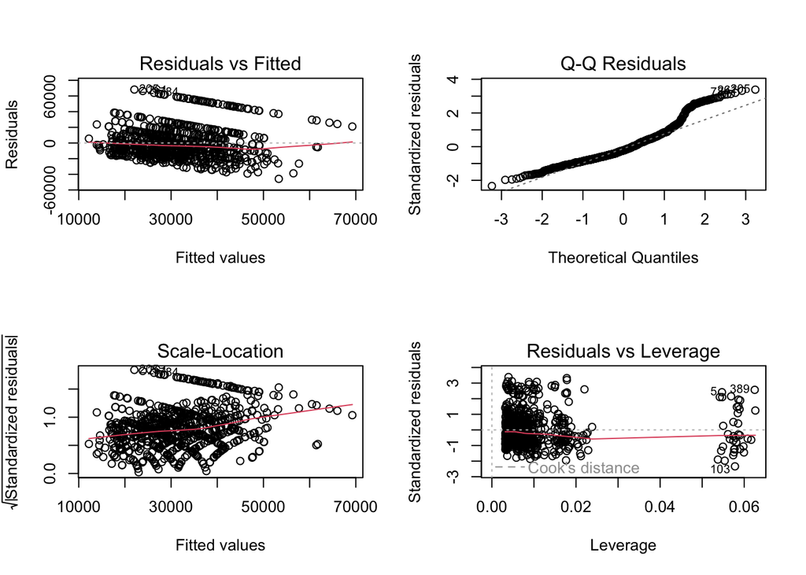

```r
par(mfrow=c(2,2))
plot(m)
```

#### How Dr. Cribbie did:

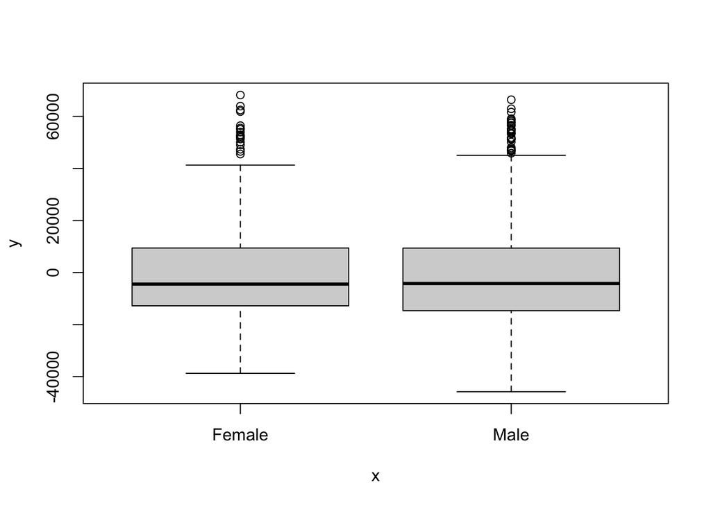

```r
#Homoscedasticity
plot(factor(d$SEX), residuals(m))
```

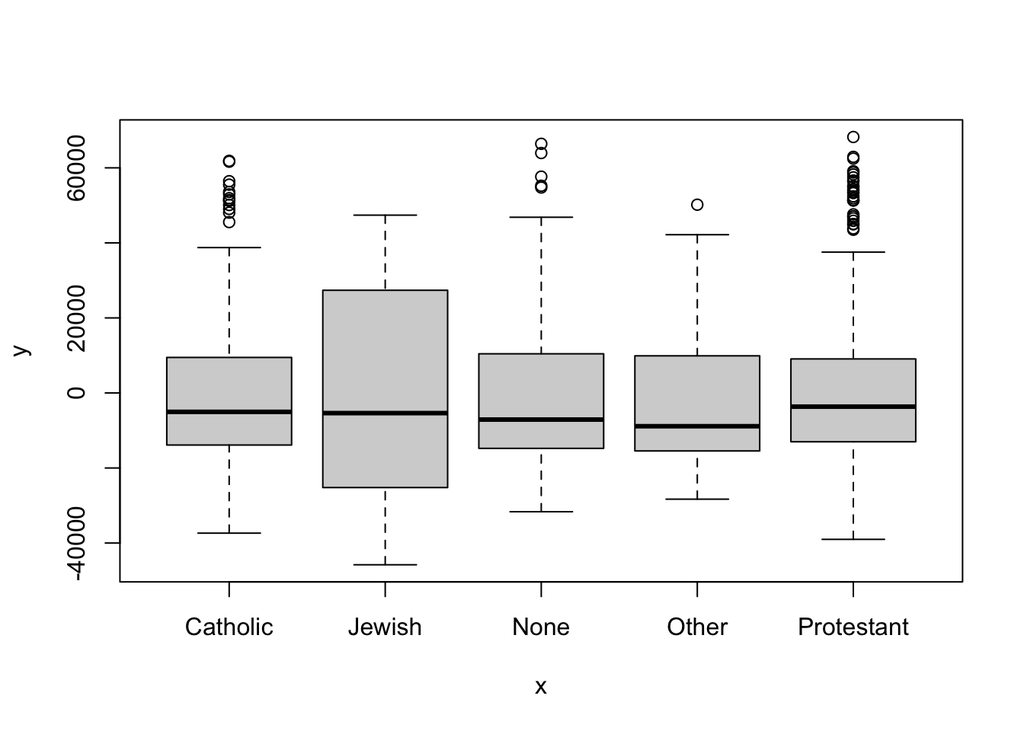

```r
plot(factor(d$RELIG), residuals(m))
```

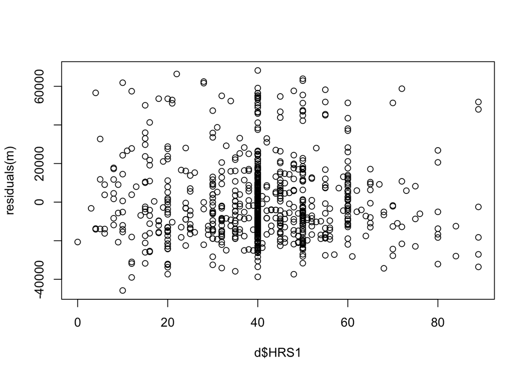

```r
plot(d$HRS1,residuals(m))
```

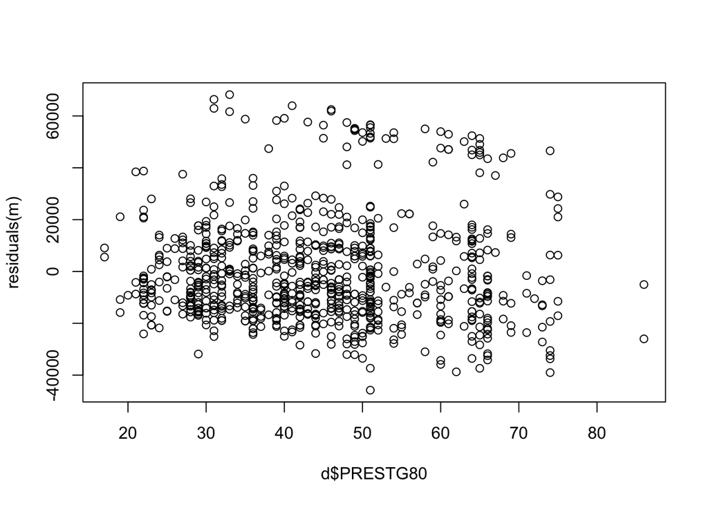

```r
plot(d$PRESTG80, residuals(m))
```

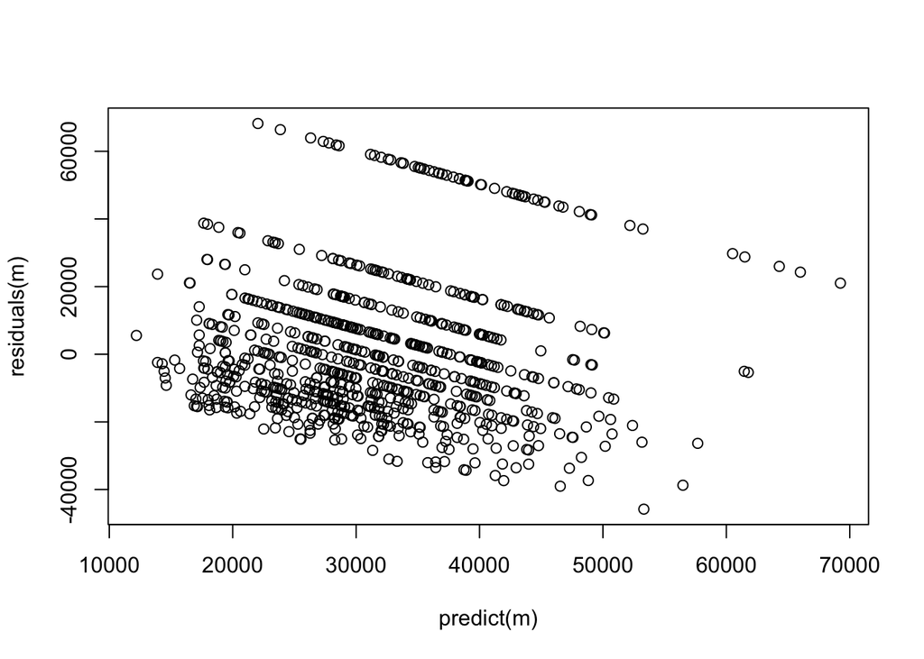

```r
plot(predict(m),residuals(m))
```

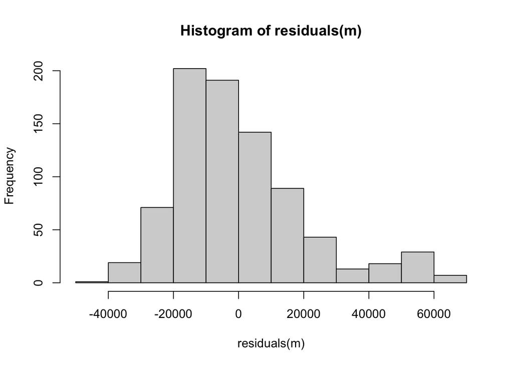

```r
#Normality
hist(residuals(m))
```